# Housing prices per m² in Haute-Garonne, 2025

Cleaning and describing DVF transactions with R

Author

Benjamin Green

Published

October 26, 2026

## Question and main results

What was the price per m² of houses and flats sold in Haute-Garonne in 2025, and how does it differ by dwelling type, location and month?

- The sample is **19,230 sales** out of 28,016 recorded transactions (69%), each containing exactly one house or flat.
- The median price is **2,951 EUR/m² for flats** and **2,695 EUR/m² for houses**.
- That gap comes from where each type is sold, not from a flat premium: 65% of flats but only 13% of houses are in Toulouse. Within Toulouse houses are more expensive (3,692 vs 3,250); outside Toulouse the two types are almost the same (2,597 vs 2,619).
- Monthly median prices are flat through the year; sales volumes are not.
- The results move by less than 1% when any cleaning threshold is changed.

## Data

Source: DVF géolocalisées (Etalab), derived from the DGFiP *Demandes de valeurs foncières*, national file for 2025, filtered to département 31. One row of the raw file is a parcel or a premises, not a sale: the price of the whole sale is repeated on every row. The unit of analysis is therefore the sale (`id_mutation`), and the cleaning works at that level.

## Cleaning

A sale is kept if it is an ordinary sale (*Vente*) of exactly one house or flat, with no professional premises in the same deed, a known price, and a plausible price, surface and price per m². Each step removes sales, and the table shows how many.

| Step | Sales left | Removed |
| --- | --- | --- |
| All sales in departement 31 | 28,016 | NA |
| Nature = Vente | 26,168 | 1,848 |
| At least one house or flat | 20,235 | 5,933 |
| Exactly one dwelling | 19,568 | 667 |
| No professional premises | 19,378 | 190 |
| Price not missing | 19,358 | 20 |
| Price >= 10000 EUR | 19,318 | 40 |
| Surface in (0, 400] m2 | 19,313 | 5 |
| Price/m2 in [300, 10000] | 19,230 | 83 |

The thresholds are `prix_min` = 10,000 EUR, `surface_max` = 400 m², and price per m² between 300 and 10,000 EUR. They come from orders of magnitude of the market, not from the data, which is why the robustness section below varies them.

## Results

### By dwelling type

| Type | Sales | Q1 | Median | Q3 | Median surface (m²) |
| --- | --- | --- | --- | --- | --- |
| Appartement | 10,407 | 2,401 | 2,951 | 3,690 | 55 |
| Maison | 8,823 | 2,072 | 2,695 | 3,292 | 100 |

Medians and quartiles are used instead of means because the distribution of price per m² is right-skewed.

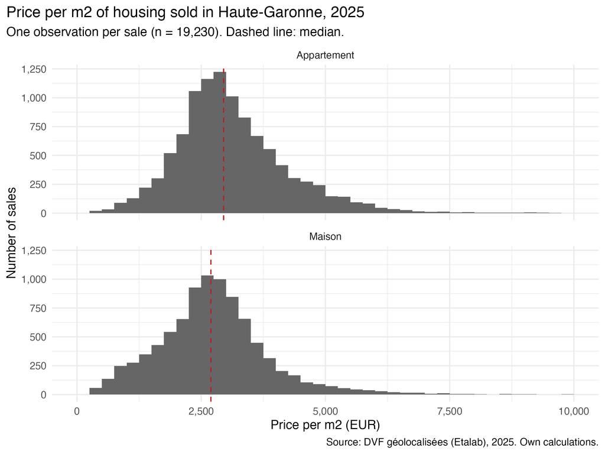

Figure 1

### Toulouse against the rest of the département

| Zone | Type | Sales | Median EUR/m² | Median surface (m²) |
| --- | --- | --- | --- | --- |
| Rest of the 31 | Appartement | 3,612 | 2,619 | 55 |
| Rest of the 31 | Maison | 7,656 | 2,597 | 100 |
| Toulouse | Appartement | 6,795 | 3,250 | 55 |
| Toulouse | Maison | 1,167 | 3,692 | 95 |

This is a descriptive comparison, not an adjusted one: location, size and condition are not controlled for. Houses also include the land, which flats do not, so the two types are not like-for-like.

### By commune

Among communes with at least 30 sales, medians run from about 1,064 EUR/m² (Montrejeau, 49 sales) to about 3,560 (Quint, 64 sales).

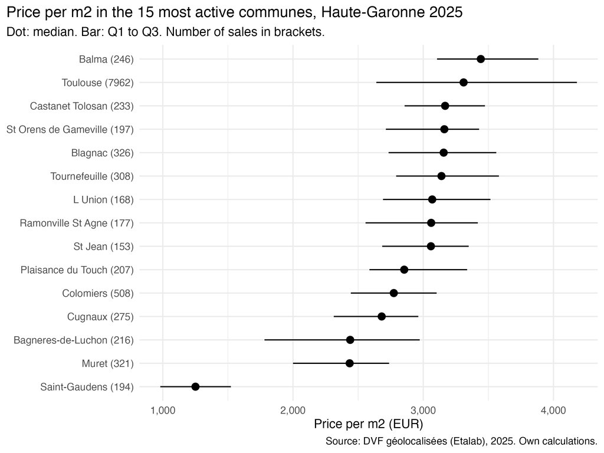

Figure 2

### By month

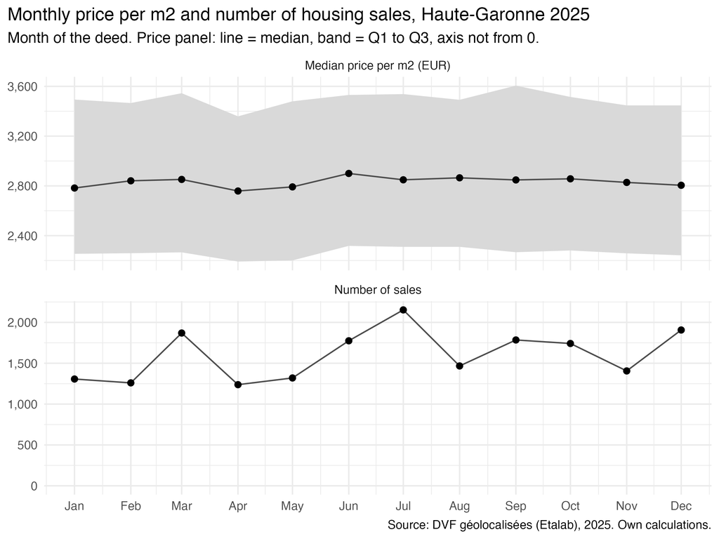

Figure 3

Monthly medians stay between 2,759 and 2,900 EUR/m². The number of sales ranges from 1,238 to 2,153, with the peak in July. Toulouse’s share of monthly sales stays within a narrow band, so the mix between zones does not explain the monthly pattern.

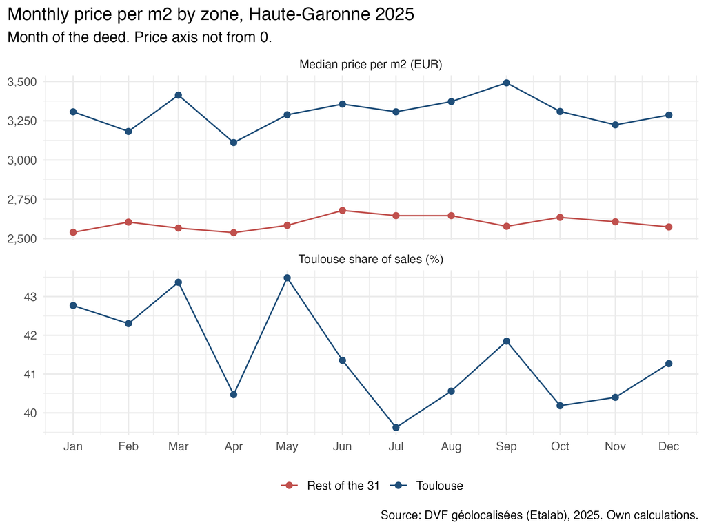

Figure 4

December is the second busiest month in the final sample, 21% above the January–November average. In the full file the December excess is larger, and part of it comes from new-build sales (*VEFA*), which are 12.9% of December transactions against 4.7% in the other months and are excluded by the cleaning. The excess does not disappear after the cleaning, and **I have not established why**: this analysis does not test any explanation.

## Robustness

Each threshold is changed on its own, the other three staying at their baseline value. The largest change in a median, for any type, is 0.97%, and for the whole sample 0.53%.

| Parameter | Value | Sales left | Change in sales | Change in median (%) |
| --- | --- | --- | --- | --- |
| prix_min | 1,000 | 19,231 | 1 | 0.00 |
| prix_min | 5,000 | 19,231 | 1 | 0.00 |
| prix_min | 20,000 | 19,211 | -19 | 0.04 |
| prix_min | 30,000 | 19,175 | -55 | 0.10 |
| surface_max | 250 | 19,158 | -72 | 0.07 |
| surface_max | 600 | 19,234 | 4 | 0.00 |
| prix_m2_min | 100 | 19,275 | 45 | -0.08 |
| prix_m2_min | 500 | 19,156 | -74 | 0.13 |
| prix_m2_min | 800 | 18,939 | -291 | 0.53 |
| prix_m2_max | 8,000 | 19,181 | -49 | -0.08 |
| prix_m2_max | 15,000 | 19,254 | 24 | 0.05 |

The price-per-m² bounds remove 83 sales: 48 below the floor and 35 above the ceiling.

| Side | Type | Sales | Median price (EUR) | Median surface (m²) | Median EUR/m² |
| --- | --- | --- | --- | --- | --- |
| au-dessus du plafond | Appartement | 14 | 251,825 | 20.0 | 11,505.5556 |
| au-dessus du plafond | Maison | 21 | 1,200,000 | 86.0 | 14,857.1429 |
| sous le plancher | Appartement | 10 | 15,000 | 76.5 | 228.2986 |
| sous le plancher | Maison | 38 | 24,785 | 120.0 | 219.2158 |

Sales under the floor have a median price of roughly 15,000 to 25,000 EUR, which is not a plausible price for a whole dwelling; they may be partial interests or entry errors. The high side mixes very small surfaces with high prices and a few expensive houses. I did not check these sales one by one.

## Limits

- One year of data, and a description only: no causal claim is made.
- Sales with several dwellings or with professional premises are excluded, so the sample covers simple residential sales and not the whole market.
- The price per m² is the price of the whole sale divided by the built surface. Condition, floor, outbuildings and land are not observed.
- Two identical flats on the same parcel in one sale would count as one dwelling and double the price per m²; the upper bound limits the effect.
- Communes with few sales have unreliable medians, hence the minimum of 30 sales for the commune comparison.

## Reproducing this report

The raw file is not in the repository. Place `full-2025.csv.gz` in `data/raw/`, then run `R/02_filter_31.R`, `R/03_clean.R`, `R/04_describe.R` and `R/05_robustness.R` in this order, and render `report/dvf_report.qmd`.